# COVID-19 analysis based on crowdsourced data

[Data source](https://docs.google.com/spreadsheets/d/e/2PACX-1vQU0SIALScXx8VXDX7yKNKWWPKE1YjFlWc6VTEVSN45CklWWf-uWmprQIyLtoPDA18tX9cFDr-aQ9S6/pubhtml)

Paper: Early epidemiological analysis of the coronavirus disease 2019 outbreak based on crowdsourced data: a population-level observational study

Date downloaded: 2020-03-11. Latest data update: 2020-03-09 1PM EST.

DISCLAIMER: Data quality is **very questionable**. As such, any conclusions will be very questionable too. This is meant as a didactic exercise only. Students are invited to find better data and/or keep a very critical mindset while going through the results.

```r
library(tidyverse)
```

# Data preparation

```r
d_raw <- read_csv("covid19.csv",
              col_types = cols(id = 'c', case_in = 'c', age = 'd', if_onset_approximated = 'l',
                               international_traveler = 'l', domestic_traveler = 'l', traveler = 'l',
                               `visiting Wuhan` = 'l', `from Wuhan` = 'l',
                               .default = 'c'
                               ))
#?
#d_raw <- d_raw[-2224,]
```

```r
table(d_raw$death)
```

```
##
##         0         1  2/1/2020 2/13/2020 2/14/2020 2/19/2020 2/21/2020 2/22/2020
##      1536        42         1         1         1         2         2         2
## 2/23/2020 2/24/2020 2/25/2020 2/26/2020 2/27/2020 2/28/2020 2/29/2020  3/1/2020
##         5         1         2         4         2         1         1         3
##  3/3/2020  3/4/2020  3/6/2020  3/8/2020
##         1         1         1         2
```

```r
table(d_raw$gender, useNA = "always")
```

```
##
## female   male   <NA>
##    604    798    908
```

```r
as_date <- function(x) as.Date(x, format = "%m/%d/%y")
d <-
  d_raw %>%
  mutate(reporting_date = as_date(reporting_date),
         hosp_visit_date = as_date(hosp_visit_date),
         exposure_start = as_date(exposure_start),
         exposure_end = as_date(exposure_end),
         symptom_onset = as_date(symptom_onset),
         death_status = death != "0",
         death_date = as.Date(ifelse(!death %in% c("0", "1"), as.Date(death, format = "%m/%d/%y", origin = "1970-01-01"), NA), origin = "1970-01-01"),
         gender = factor(gender, levels = c("female", "male")))
```

# Binary outcome: alive/dead

## Sex impact

### Frequency tables and independence tests

```r
with(d, table(death_status, gender)) # absolute frequencies
```

```
##             gender
## death_status female male
##        FALSE    516  664
##        TRUE      22   47
```

```r
with(d, round(100 * prop.table(table(death_status, gender), 2), 1)) # relative frequencies (2-frequencies per column)
```

```
##             gender
## death_status female male
##        FALSE   95.9 93.4
##        TRUE     4.1  6.6
```

```r
with(d, chisq.test(table(death_status, gender))) # test of independence
```

```
##
##  Pearson's Chi-squared test with Yates' continuity correction
##
## data:  table(death_status, gender)
## X-squared = 3.2625, df = 1, p-value = 0.07088
```

H0 = probabilities equals p-value > 0.05 –> cannot reject H0 there is no significant difference

chisq.test is an asymptotic test (tends to chisq when n -> inf) - easy - computationaly cheap - widely available

- but approximate

can use Fisher exact test (no doable by hand) - extact test

- but computationaly demanding
- memory intensive if sample size is big

```r
with(d, fisher.test(table(death_status, gender)))
```

```
##
##  Fisher's Exact Test for Count Data
##
## data:  table(death_status, gender)
## p-value = 0.06051
## alternative hypothesis: true odds ratio is not equal to 1
## 95 percent confidence interval:
##  0.9660476 2.9313166
## sample estimates:
## odds ratio
##   1.659538
```

odds ratio: odds man / odds woman

odds man = 6.6% / 93.4% odds woman = 4.1% / 95.9%

what’s difference in risk of death by covid19 between man and woman: odds ratio (1.66) with CI of (0.97-2.93) p-value = 0.06

### Logistic regression

Yi | Gi ~ Ber(pi) , logit(pi)= B0 + B1*Gi , iid Gi : gender of subject (0 female, 1 male)

B in R²

yi , gi observed

–> LIKELIHOOD FUNCTION: f(y;g;B) = product[ f(yi;gi;B) ] -> yi, gi known, we want to estimate B i=1;n

B0 intercept B1 gendermale

```r
summary(glm(death_status ~ gender, data = d, family = "binomial"))
```

```
##
## Call:
## glm(formula = death_status ~ gender, family = "binomial", data = d)
##
## Deviance Residuals:
##     Min       1Q   Median       3Q      Max
## -0.3698  -0.3698  -0.3698  -0.2890   2.5286
##
## Coefficients:
##             Estimate Std. Error z value Pr(>|z|)
## (Intercept)  -3.1551     0.2176 -14.496   <2e-16 ***
## gendermale    0.5069     0.2649   1.914   0.0556 .
## ---
## Signif. codes:  0 '***' 0.001 '**' 0.01 '*' 0.05 '.' 0.1 ' ' 1
##
## (Dispersion parameter for binomial family taken to be 1)
##
##     Null deviance: 533.76  on 1248  degrees of freedom
## Residual deviance: 529.92  on 1247  degrees of freedom
##   (1061 observations deleted due to missingness)
## AIC: 533.92
##
## Number of Fisher Scoring iterations: 5
```

logit(prob_of_dying_i) = B0 + B1*Gi B0 = -3.1551, stddev = 0.22 B1 = 0.5069, stddev = 0.26

Ho: B1 = 0, interpreted as lack of association between gender and outcome

WALD test: Bhat / SEhat ~ N(0,1)

```r
exp(0.5069)
```

```
## [1] 1.660137
```

logistic regression -> exp(B1) : odds ratio

### Maximum Likelihood

```r
library(maxLik)
```

model death by gender

```r
dx = d %>% select(gender, death_status) %>% na.omit()

x = (dx$gender == "male") + 0
y = dx$death_status +0

logLik <- function(beta) {
  linear_predictor = beta[1]  + beta[2]*x
  log_probabilities = dbinom(y,size=1, prob=plogis(linear_predictor),log=TRUE)
  log_likelihood = sum(log_probabilities)
  return(log_likelihood)
}
```

```r
fit = maxLik(logLik,start=c(intercept=0,gender=0))
```

```r
summary(fit)
```

```
## --------------------------------------------
## Maximum Likelihood estimation
## Newton-Raphson maximisation, 6 iterations
## Return code 1: gradient close to zero
## Log-Likelihood: -264.9617
## 2  free parameters
## Estimates:
##           Estimate Std. error t value Pr(> t)
## intercept  -3.1551     0.2178 -14.489  <2e-16 ***
## gender      0.5069     0.2649   1.914  0.0557 .
## ---
## Signif. codes:  0 '***' 0.001 '**' 0.01 '*' 0.05 '.' 0.1 ' ' 1
## --------------------------------------------
```

comparison with GLM

```r
summary(glm(death_status~gender, data=dx,family="binomial"))
```

```
##
## Call:
## glm(formula = death_status ~ gender, family = "binomial", data = dx)
##
## Deviance Residuals:
##     Min       1Q   Median       3Q      Max
## -0.3698  -0.3698  -0.3698  -0.2890   2.5286
##
## Coefficients:
##             Estimate Std. Error z value Pr(>|z|)
## (Intercept)  -3.1551     0.2176 -14.496   <2e-16 ***
## gendermale    0.5069     0.2649   1.914   0.0556 .
## ---
## Signif. codes:  0 '***' 0.001 '**' 0.01 '*' 0.05 '.' 0.1 ' ' 1
##
## (Dispersion parameter for binomial family taken to be 1)
##
##     Null deviance: 533.76  on 1248  degrees of freedom
## Residual deviance: 529.92  on 1247  degrees of freedom
## AIC: 533.92
##
## Number of Fisher Scoring iterations: 5
```

## Age

```r
summary(glm(death_status ~ age, data = d, family = "binomial"))
```

```
##
## Call:
## glm(formula = death_status ~ age, family = "binomial", data = d)
##
## Deviance Residuals:
##     Min       1Q   Median       3Q      Max
## -1.2225  -0.3623  -0.2094  -0.1143   3.0651
##
## Coefficients:
##              Estimate Std. Error z value Pr(>|z|)
## (Intercept) -7.564414   0.652945 -11.585   <2e-16 ***
## age          0.079895   0.009362   8.534   <2e-16 ***
## ---
## Signif. codes:  0 '***' 0.001 '**' 0.01 '*' 0.05 '.' 0.1 ' ' 1
##
## (Dispersion parameter for binomial family taken to be 1)
##
##     Null deviance: 528.76  on 1159  degrees of freedom
## Residual deviance: 427.16  on 1158  degrees of freedom
##   (1150 observations deleted due to missingness)
## AIC: 431.16
##
## Number of Fisher Scoring iterations: 7
```

age estimate > 0 –> positive relationship p-value << 0 -> strong relationship

using age in decade:

```r
fit <- glm(death_status ~ I(age/10), data = d, family = "binomial")
summary(fit)
```

```
##
## Call:
## glm(formula = death_status ~ I(age/10), family = "binomial",
##     data = d)
##
## Deviance Residuals:
##     Min       1Q   Median       3Q      Max
## -1.2225  -0.3623  -0.2094  -0.1143   3.0651
##
## Coefficients:
##             Estimate Std. Error z value Pr(>|z|)
## (Intercept) -7.56441    0.65295 -11.585   <2e-16 ***
## I(age/10)    0.79895    0.09362   8.534   <2e-16 ***
## ---
## Signif. codes:  0 '***' 0.001 '**' 0.01 '*' 0.05 '.' 0.1 ' ' 1
##
## (Dispersion parameter for binomial family taken to be 1)
##
##     Null deviance: 528.76  on 1159  degrees of freedom
## Residual deviance: 427.16  on 1158  degrees of freedom
##   (1150 observations deleted due to missingness)
## AIC: 431.16
##
## Number of Fisher Scoring iterations: 7
```

```r
exp(coef(fit)[2])
```

```
## I(age/10)
##  2.223203
```

for a decade increase in age -> the odds ratio is greater than 2

confidence interval

```r
exp(confint(fit)[2,])
```

```
##    2.5 %   97.5 %
## 1.863645 2.691992
```

OR CI between 1.86 and 2.7

RISK OF DEATH BY COVID19 vs AGE

~2 odds per decade increase pvalue < 2*e-16 (strongly significant)

**using a more general model to check if linear model is ok** gam: generalized additive mdel s(age) - smoothing(age)

```r
library(mgcv)
fit = gam(death_status ~ s(age), data=d, family = "binomial")
summary(fit)
```

```
##
## Family: binomial
## Link function: logit
##
## Formula:
## death_status ~ s(age)
##
## Parametric coefficients:
##             Estimate Std. Error z value Pr(>|z|)
## (Intercept)   -3.592      0.218  -16.47   <2e-16 ***
## ---
## Signif. codes:  0 '***' 0.001 '**' 0.01 '*' 0.05 '.' 0.1 ' ' 1
##
## Approximate significance of smooth terms:
##        edf Ref.df Chi.sq p-value
## s(age)   1  1.001  72.79  <2e-16 ***
## ---
## Signif. codes:  0 '***' 0.001 '**' 0.01 '*' 0.05 '.' 0.1 ' ' 1
##
## R-sq.(adj) =  0.108   Deviance explained = 19.2%
## UBRE = -0.62831  Scale est. = 1         n = 1160
```

edf : estimated degrees of freedom (1 -> linear model)

visually

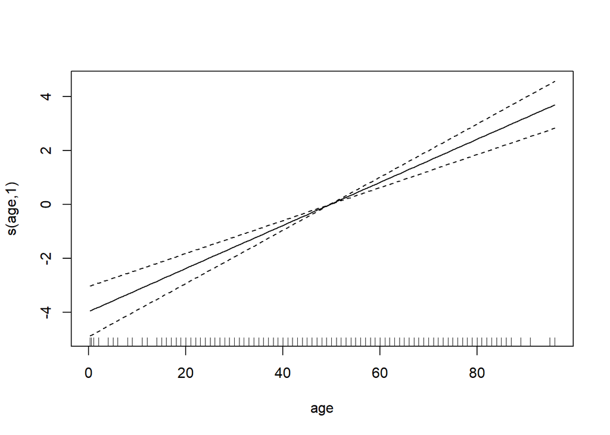

```r
plot(fit)
```

**fitting of polynomial (quadrtic) form (with ² term)**

```r
fit <- glm(death_status ~ age + I(age^2), data = d, family = "binomial")
summary(fit)
```

```
##
## Call:
## glm(formula = death_status ~ age + I(age^2), family = "binomial",
##     data = d)
##
## Deviance Residuals:
##     Min       1Q   Median       3Q      Max
## -1.1334  -0.3713  -0.2060  -0.1010   3.1212
##
## Coefficients:
##               Estimate Std. Error z value Pr(>|z|)
## (Intercept) -8.6688348  2.1839829  -3.969 7.21e-05 ***
## age          0.1156056  0.0671105   1.723    0.085 .
## I(age^2)    -0.0002749  0.0005074  -0.542    0.588
## ---
## Signif. codes:  0 '***' 0.001 '**' 0.01 '*' 0.05 '.' 0.1 ' ' 1
##
## (Dispersion parameter for binomial family taken to be 1)
##
##     Null deviance: 528.76  on 1159  degrees of freedom
## Residual deviance: 426.85  on 1157  degrees of freedom
##   (1150 observations deleted due to missingness)
## AIC: 432.85
##
## Number of Fisher Scoring iterations: 8
```

square term not significant.

**PIECE WISE LINEAR TERMS**

```r
d2 = mutate(d,age_70 = ifelse(age>70,age-70,0))
```

```r
summary(glm(death_status ~ age + age_70, data=d2, family = "binomial"))
```

```
##
## Call:
## glm(formula = death_status ~ age + age_70, family = "binomial",
##     data = d2)
##
## Deviance Residuals:
##     Min       1Q   Median       3Q      Max
## -1.1294  -0.3689  -0.2018  -0.1037   3.1170
##
## Coefficients:
##             Estimate Std. Error z value Pr(>|z|)
## (Intercept) -8.01321    1.01214  -7.917 2.43e-15 ***
## age          0.08787    0.01641   5.354 8.58e-08 ***
## age_70      -0.02061    0.03363  -0.613     0.54
## ---
## Signif. codes:  0 '***' 0.001 '**' 0.01 '*' 0.05 '.' 0.1 ' ' 1
##
## (Dispersion parameter for binomial family taken to be 1)
##
##     Null deviance: 528.76  on 1159  degrees of freedom
## Residual deviance: 426.78  on 1157  degrees of freedom
##   (1150 observations deleted due to missingness)
## AIC: 432.78
##
## Number of Fisher Scoring iterations: 7
```

H0: B2 = 0 age_70 estimate <0 : negative contribution when age > 70 age_70 pvalue big –> no significance

## Comparing countries

```r
table(d$country)
```

```
##
## Afghanistan     Algeria   Australia     Austria     Bahrain     Belgium
##           1           1          15           2          17           1
##    Cambodia      Canada       China     Croatia       Egypt     Finland
##           1          12         197           1           1           1
##      France     Germany   Hong Kong       India        Iran      Israel
##          56         168         102           3          18           1
##       Italy       Japan      Kuwait     Lebanon    Malaysia       Nepal
##          86         257           9           1          23           1
## Phillipines      Russia   Singapore South Korea       Spain   Sri Lanka
##           3           2         112         114         116           1
##      Sweden Switzerland      Taiwan    Thailand         UAE          UK
##           1          10          34          41          21          20
##         USA     Vietnam
##         757          16
```

Caveats: 1. obsolete data 2. different testing guidelines per country 3. different reporting accuracy (i.e., often only deaths from hospitals are counted) 4. …?

```r
d1 <- mutate(d, country = relevel(factor(country), ref = "China")) # odds ratio compare country vs china
summary(glm(death_status ~ country, data = d1, family = "binomial"))
```

```
##
## Call:
## glm(formula = death_status ~ country, family = "binomial", data = d1)
##
## Deviance Residuals:
##      Min        1Q    Median        3Q       Max
## -0.90052  -0.37804  -0.19823  -0.00005   2.80700
##
## Coefficients:
##                      Estimate Std. Error z value Pr(>|z|)
## (Intercept)           -1.3990     0.1788  -7.824  5.1e-15 ***
## countryAfghanistan   -19.1670 17730.3699  -0.001 0.999137
## countryAlgeria       -19.1670 17730.3699  -0.001 0.999137
## countryAustralia     -19.1670  4577.9618  -0.004 0.996659
## countryAustria       -19.1670 12537.2648  -0.002 0.998780
## countryBahrain       -19.1670  4300.2464  -0.004 0.996444
## countryBelgium       -19.1670 17730.3699  -0.001 0.999137
## countryCambodia      -19.1670 17730.3699  -0.001 0.999137
## countryCanada        -19.1670  5118.3169  -0.004 0.997012
## countryCroatia       -19.1670 17730.3699  -0.001 0.999137
## countryEgypt         -19.1670 17730.3699  -0.001 0.999137
## countryFinland       -19.1670 17730.3699  -0.001 0.999137
## countryFrance         -1.8968     0.7419  -2.557 0.010573 *
## countryGermany       -19.1670  1367.9277  -0.014 0.988821
## countryHong Kong      -2.5130     0.7362  -3.414 0.000641 ***
## countryIndia         -19.1670 10236.6338  -0.002 0.998506
## countryIran            0.1463     0.5945   0.246 0.805643
## countryIsrael        -19.1670 17730.3699  -0.001 0.999137
## countryItaly          -2.3386     0.7375  -3.171 0.001519 **
## countryJapan          -2.5210     0.4857  -5.190  2.1e-07 ***
## countryKuwait        -19.1670  5910.1233  -0.003 0.997412
## countryLebanon       -19.1670 17730.3699  -0.001 0.999137
## countryMalaysia      -19.1670  3697.0377  -0.005 0.995863
## countryNepal         -19.1670 17730.3699  -0.001 0.999137
## countryPhillipines     0.7059     1.2377   0.570 0.568469
## countryRussia        -19.1670 12537.2648  -0.002 0.998780
## countrySingapore     -19.1670  1675.3625  -0.011 0.990872
## countrySouth Korea    -1.0577     0.3906  -2.708 0.006778 **
## countrySpain         -19.1670  1646.2235  -0.012 0.990710
## countrySri Lanka     -19.1670 17730.3699  -0.001 0.999137
## countrySweden        -19.1670 17730.3699  -0.001 0.999137
## countrySwitzerland   -19.1670  5606.8353  -0.003 0.997272
## countryTaiwan         -2.0975     1.0307  -2.035 0.041844 *
## countryThailand      -19.1670  2769.0186  -0.007 0.994477
## countryUAE           -19.1670  3869.0839  -0.005 0.996047
## countryUK            -19.1670  3964.6312  -0.005 0.996143
## countryUSA            -1.2037     0.3733  -3.224 0.001264 **
## countryVietnam       -19.1670  4432.5925  -0.004 0.996550
## ---
## Signif. codes:  0 '***' 0.001 '**' 0.01 '*' 0.05 '.' 0.1 ' ' 1
##
## (Dispersion parameter for binomial family taken to be 1)
##
##     Null deviance: 606.52  on 1610  degrees of freedom
## Residual deviance: 468.95  on 1573  degrees of freedom
##   (699 observations deleted due to missingness)
## AIC: 544.95
##
## Number of Fisher Scoring iterations: 19
```

## Adjusted model

```r
fit <- glm(death_status ~ I(age/10) + gender + country, data = d1, family = "binomial")
summary(fit)
```

```
##
## Call:
## glm(formula = death_status ~ I(age/10) + gender + country, family = "binomial",
##     data = d1)
##
## Deviance Residuals:
##     Min       1Q   Median       3Q      Max
## -1.6949  -0.1932  -0.0610   0.0000   3.6227
##
## Coefficients:
##                      Estimate Std. Error z value Pr(>|z|)
## (Intercept)           -7.9714     0.9070  -8.789  < 2e-16 ***
## I(age/10)              1.0603     0.1303   8.135 4.11e-16 ***
## gendermale             0.8658     0.3441   2.516  0.01186 *
## countryAustralia     -18.4937  4123.7162  -0.004  0.99642
## countryCambodia      -19.8222 17730.3699  -0.001  0.99911
## countryCanada        -18.0770  4730.8786  -0.004  0.99695
## countryFinland       -15.9876 17730.3699  -0.001  0.99928
## countryFrance         -0.7951     0.9138  -0.870  0.38425
## countryGermany       -19.2704  1550.0236  -0.012  0.99008
## countryHong Kong      -3.5901     0.7891  -4.550 5.37e-06 ***
## countryItaly          -2.1922     0.8409  -2.607  0.00913 **
## countryJapan          -3.9523     0.5970  -6.620 3.59e-11 ***
## countryLebanon       -17.3660 17730.3699  -0.001  0.99922
## countryMalaysia      -18.7206  3172.3686  -0.006  0.99529
## countryNepal         -16.8534 17730.3699  -0.001  0.99924
## countryPhillipines     1.8041     1.3598   1.327  0.18461
## countrySingapore     -18.5859  1527.9201  -0.012  0.99029
## countrySouth Korea    -0.7657     0.4593  -1.667  0.09551 .
## countrySpain         -19.8696  1761.9807  -0.011  0.99100
## countrySri Lanka     -16.8359 17730.3699  -0.001  0.99924
## countrySweden        -15.2454 17730.3699  -0.001  0.99931
## countrySwitzerland   -18.8654  6051.8537  -0.003  0.99751
## countryTaiwan         -2.5370     1.1298  -2.245  0.02474 *
## countryThailand      -19.3291  3947.2803  -0.005  0.99609
## countryUAE           -19.3137  5885.6028  -0.003  0.99738
## countryUK            -19.0800 17730.3699  -0.001  0.99914
## countryUSA            -1.0312     0.5283  -1.952  0.05092 .
## countryVietnam       -18.4301  5439.6772  -0.003  0.99730
## ---
## Signif. codes:  0 '***' 0.001 '**' 0.01 '*' 0.05 '.' 0.1 ' ' 1
##
## (Dispersion parameter for binomial family taken to be 1)
##
##     Null deviance: 518.77  on 1123  degrees of freedom
## Residual deviance: 278.36  on 1096  degrees of freedom
##   (1186 observations deleted due to missingness)
## AIC: 334.36
##
## Number of Fisher Scoring iterations: 19
```

```r
exp(coef(fit)[2:3])
```

```
##  I(age/10) gendermale
##   2.887235   2.376838
```

```r
library(mgcv)
fit <- gam(death_status ~ age + gender + country, data = d1, family = "binomial")
```

# Continuous outcome: survival time

```r
library(survival)
END_OF_STUDY <- as.Date("2020-03-10", format = "%Y-%m-%d", origin = "1970-01-01")
```

From first symptom to date of data collection: March 10th, 2020

```r
d_surv <-
  d %>%
  filter(!is.na(symptom_onset), !is.na(death_status),
         !(is.na(death_date) & death_status)) %>%
  mutate(
    death_date = as.Date(ifelse(is.na(death_date), END_OF_STUDY, death_date), origin = "1970-01-01"),
    time = difftime(death_date, symptom_onset, units = "days")
  )
```

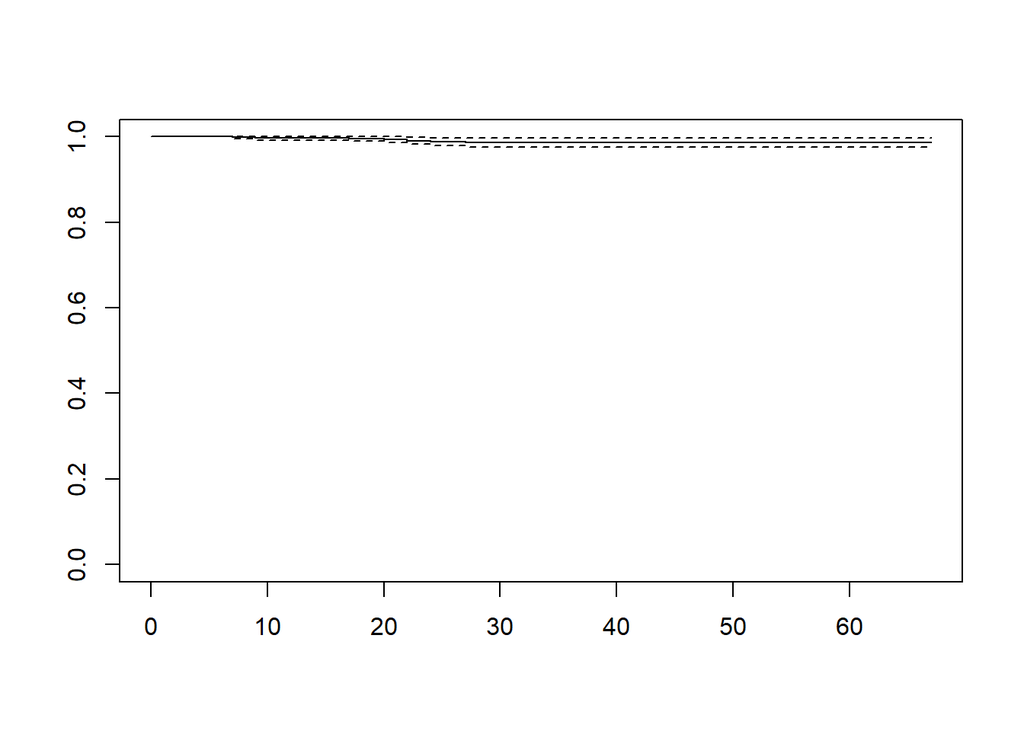

```r
fit <- survfit(Surv(time, death_status) ~ 1, data = d_surv)
plot(fit)
```

Let’s zoom in:

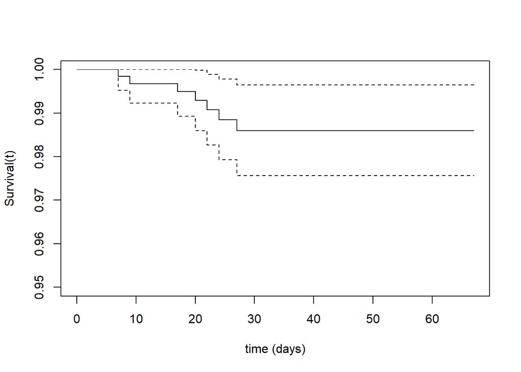

```r
plot(fit, ylim = c(0.95, 1),
     xlab = "time (days)", ylab = "Survival(t)")
```

Cannot extract a median, 7 deaths out of 623 cases (~1.1%):

```r
fit
```

```
## Call: survfit(formula = Surv(time, death_status) ~ 1, data = d_surv)
##
##       n  events  median 0.95LCL 0.95UCL
##     623       7      NA      NA      NA
```

## Effects of covariates on risk of death

```r
summary(d_surv)
```

```
##       id              case_in          reporting_date         summary
##  Length:623         Length:623         Min.   :2020-01-13   Length:623
##  Class :character   Class :character   1st Qu.:2020-01-27   Class :character
##  Mode  :character   Mode  :character   Median :2020-02-14   Mode  :character
##                                        Mean   :2020-02-11
##                                        3rd Qu.:2020-02-25
##                                        Max.   :2020-03-06
##
##    location           country             gender         age
##  Length:623         Length:623         female:252   Min.   : 2.0
##  Class :character   Class :character   male  :365   1st Qu.:37.0
##  Mode  :character   Mode  :character   NA's  :  6   Median :52.0
##                                                     Mean   :50.3
##                                                     3rd Qu.:65.0
##                                                     Max.   :96.0
##                                                     NA's   :18
##  symptom_onset        if_onset_approximated hosp_visit_date
##  Min.   :2020-01-03   Mode :logical         Min.   :2020-01-06
##  1st Qu.:2020-01-23   FALSE:574             1st Qu.:2020-01-25
##  Median :2020-02-03   TRUE :24              Median :2020-02-06
##  Mean   :2020-02-04   NA's :25              Mean   :2020-02-07
##  3rd Qu.:2020-02-17                         3rd Qu.:2020-02-20
##  Max.   :2020-03-05                         Max.   :2020-03-02
##                                             NA's   :131
##  exposure_start        exposure_end        international_traveler
##  Min.   :2020-01-03   Min.   :2020-01-02   Mode :logical
##  1st Qu.:2020-01-12   1st Qu.:2020-01-17   FALSE:2
##  Median :2020-01-20   Median :2020-01-21   TRUE :5
##  Mean   :2020-02-02   Mean   :2020-01-22   NA's :616
##  3rd Qu.:2020-01-25   3rd Qu.:2020-01-23
##  Max.   :2020-12-29   Max.   :2020-03-04
##  NA's   :536          NA's   :407
##  domestic_traveler  traveler       visiting Wuhan  from Wuhan
##  Mode :logical     Mode :logical   Mode :logical   Mode :logical
##  FALSE:8           FALSE:57        FALSE:507       FALSE:543
##  NA's :615         TRUE :118       TRUE :116       TRUE :76
##                    NA's :448                       NA's :4
##
##
##
##     death            recovered           symptom             source
##  Length:623         Length:623         Length:623         Length:623
##  Class :character   Class :character   Class :character   Class :character
##  Mode  :character   Mode  :character   Mode  :character   Mode  :character
##
##
##
##
##      link           death_status      death_date             time
##  Length:623         Mode :logical   Min.   :2020-02-01   Length:623
##  Class :character   FALSE:616       1st Qu.:2020-03-10   Class :difftime
##  Mode  :character   TRUE :7         Median :2020-03-10   Mode  :numeric
##                                     Mean   :2020-03-09
##                                     3rd Qu.:2020-03-10
##                                     Max.   :2020-03-10
##
```

## Gender

```r
summary(coxph(Surv(time, death_status) ~ gender, data = d_surv))
```

```
## Call:
## coxph(formula = Surv(time, death_status) ~ gender, data = d_surv)
##
##   n= 617, number of events= 6
##    (6 observations deleted due to missingness)
##
##             coef exp(coef) se(coef)     z Pr(>|z|)
## gendermale 1.256     3.513    1.095 1.147    0.251
##
##            exp(coef) exp(-coef) lower .95 upper .95
## gendermale     3.513     0.2847    0.4104     30.07
##
## Concordance= 0.628  (se = 0.073 )
## Likelihood ratio test= 1.68  on 1 df,   p=0.2
## Wald test            = 1.32  on 1 df,   p=0.3
## Score (logrank) test = 1.5  on 1 df,   p=0.2
```

## Country

Model does not converge: again, too few cases.

```r
summary(coxph(Surv(time, death_status) ~ country, data = d_surv))
```

```
## Call:
## coxph(formula = Surv(time, death_status) ~ country, data = d_surv)
##
##   n= 623, number of events= 7
##
##                          coef  exp(coef)   se(coef)     z Pr(>|z|)
## countryCambodia    -1.129e-06  1.000e+00  7.851e+04  0.00        1
## countryCanada      -1.125e-06  1.000e+00  5.552e+04  0.00        1
## countryChina       -1.164e-06  1.000e+00  7.452e+03  0.00        1
## countryFinland     -1.114e-06  1.000e+00  7.851e+04  0.00        1
## countryFrance       2.131e+01  1.796e+09  1.101e+00 19.36   <2e-16 ***
## countryGermany      1.099e-01  1.116e+00  3.271e+04  0.00        1
## countryHong Kong    2.941e-02  1.030e+00  9.415e+03  0.00        1
## countryItaly        9.906e-02  1.104e+00  8.735e+04  0.00        1
## countryJapan        1.943e+01  2.747e+08  1.101e+00 17.66   <2e-16 ***
## countryMalaysia     1.626e-02  1.016e+00  2.531e+04  0.00        1
## countryNepal       -1.107e-06  1.000e+00  7.851e+04  0.00        1
## countryPhillipines  1.039e+02  1.279e+45  3.540e+09  0.00        1
## countrySingapore    2.509e-02  1.025e+00  8.630e+03  0.00        1
## countrySouth Korea -1.115e-06  1.000e+00  1.904e+04  0.00        1
## countrySpain        5.117e-01  1.668e+00  2.048e+05  0.00        1
## countrySri Lanka   -1.129e-06  1.000e+00  7.851e+04  0.00        1
## countrySweden      -1.146e-06  1.000e+00  7.851e+04  0.00        1
## countrySwitzerland  1.929e-01  1.213e+00  6.996e+04  0.00        1
## countryTaiwan       3.255e-03  1.003e+00  1.668e+04  0.00        1
## countryThailand    -1.147e-06  1.000e+00  2.967e+04  0.00        1
## countryUAE         -1.115e-06  1.000e+00  7.851e+04  0.00        1
## countryUSA          1.008e-02  1.010e+00  2.934e+04  0.00        1
## countryVietnam     -1.102e-06  1.000e+00  3.511e+04  0.00        1
## ---
## Signif. codes:  0 '***' 0.001 '**' 0.01 '*' 0.05 '.' 0.1 ' ' 1
##
##                    exp(coef) exp(-coef) lower .95 upper .95
## countryCambodia    1.000e+00  1.000e+00         0       Inf
## countryCanada      1.000e+00  1.000e+00         0       Inf
## countryChina       1.000e+00  1.000e+00         0       Inf
## countryFinland     1.000e+00  1.000e+00         0       Inf
## countryFrance      1.796e+09  5.569e-10 207668091 1.553e+10
## countryGermany     1.116e+00  8.959e-01         0       Inf
## countryHong Kong   1.030e+00  9.710e-01         0       Inf
## countryItaly       1.104e+00  9.057e-01         0       Inf
## countryJapan       2.747e+08  3.640e-09  31771248 2.375e+09
## countryMalaysia    1.016e+00  9.839e-01         0       Inf
## countryNepal       1.000e+00  1.000e+00         0       Inf
## countryPhillipines 1.279e+45  7.818e-46         0       Inf
## countrySingapore   1.025e+00  9.752e-01         0       Inf
## countrySouth Korea 1.000e+00  1.000e+00         0       Inf
## countrySpain       1.668e+00  5.995e-01         0       Inf
## countrySri Lanka   1.000e+00  1.000e+00         0       Inf
## countrySweden      1.000e+00  1.000e+00         0       Inf
## countrySwitzerland 1.213e+00  8.246e-01         0       Inf
## countryTaiwan      1.003e+00  9.968e-01         0       Inf
## countryThailand    1.000e+00  1.000e+00         0       Inf
## countryUAE         1.000e+00  1.000e+00         0       Inf
## countryUSA         1.010e+00  9.900e-01         0       Inf
## countryVietnam     1.000e+00  1.000e+00         0       Inf
##
## Concordance= 0.904  (se = 0.029 )
## Likelihood ratio test= 31.22  on 23 df,   p=0.1
## Wald test            = 0  on 23 df,   p=1
## Score (logrank) test = 648.9  on 23 df,   p=<2e-16
```

Is risk in France really 1.8 **billion** times that in China?

## Age

This one is strong, as expected:

```r
summary(coxph(Surv(time, death_status) ~ I(age / 10), data = d_surv))
```

```
## Call:
## coxph(formula = Surv(time, death_status) ~ I(age/10), data = d_surv)
##
##   n= 605, number of events= 6
##    (18 observations deleted due to missingness)
##
##             coef exp(coef) se(coef)     z Pr(>|z|)
## I(age/10) 1.2403    3.4567   0.3435 3.611 0.000305 ***
## ---
## Signif. codes:  0 '***' 0.001 '**' 0.01 '*' 0.05 '.' 0.1 ' ' 1
##
##           exp(coef) exp(-coef) lower .95 upper .95
## I(age/10)     3.457     0.2893     1.763     6.777
##
## Concordance= 0.846  (se = 0.117 )
## Likelihood ratio test= 17.18  on 1 df,   p=3e-05
## Wald test            = 13.04  on 1 df,   p=3e-04
## Score (logrank) test = 14.43  on 1 df,   p=1e-04
```

Is the effect linear, though?

```r
fit_age <- coxph(Surv(time, death_status) ~ pspline(age, df = 4), data = d_surv)
summary(fit_age)
```

```
## Call:
## coxph(formula = Surv(time, death_status) ~ pspline(age, df = 4),
##     data = d_surv)
##
##   n= 605, number of events= 6
##    (18 observations deleted due to missingness)
##
##                           coef  se(coef) se2     Chisq DF   p
## pspline(age, df = 4), lin 0.108 0.02791  0.02791 14.97 1.00 0.00011
## pspline(age, df = 4), non                         5.43 2.96 0.14000
##
##           exp(coef) exp(-coef) lower .95 upper .95
## ps(age)3  1.054e+01  9.488e-02 7.311e-08 1.519e+09
## ps(age)4  1.111e+02  9.003e-03 1.981e-13 6.227e+16
## ps(age)5  1.170e+03  8.545e-04 2.345e-17 5.839e+22
## ps(age)6  1.220e+04  8.197e-05 2.450e-19 6.073e+26
## ps(age)7  9.509e+04  1.052e-05 1.929e-19 4.688e+28
## ps(age)8  6.028e+04  1.659e-05 1.395e-19 2.604e+28
## ps(age)9  1.111e+04  9.002e-05 3.372e-20 3.660e+27
## ps(age)10 3.023e+04  3.308e-05 1.017e-19 8.980e+27
## ps(age)11 1.133e+06  8.824e-07 3.918e-18 3.278e+29
## ps(age)12 8.386e+06  1.193e-07 2.915e-17 2.413e+30
## ps(age)13 2.107e+06  4.747e-07 6.324e-18 7.017e+29
## ps(age)14 3.024e+05  3.306e-06 3.371e-19 2.713e+29
##
## Iterations: 4 outer, 18 Newton-Raphson
##      Theta= 0.03932137
## Degrees of freedom for terms= 4
## Concordance= 0.95  (se = 0.95 )
## Likelihood ratio test= 25.26  on 3.96 df,   p=4e-05
```

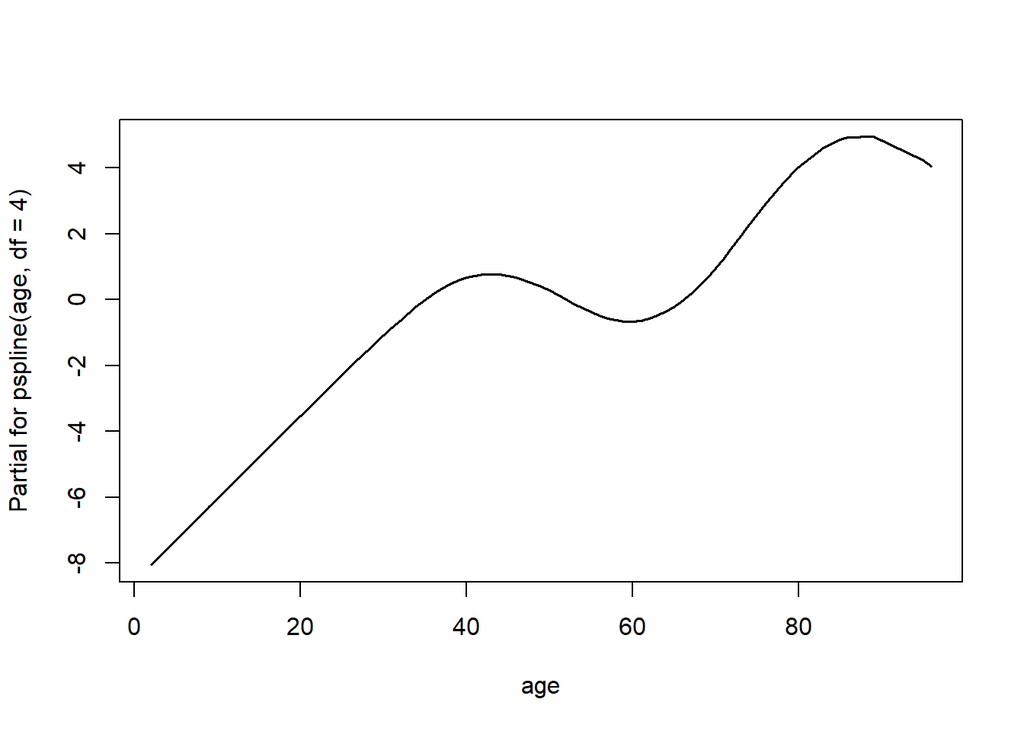

```r
termplot(fit_age, col.term = 1, col.se = 1)
```

## Piecewise-linear age effect

Segments: constant 0-70; increasing after 70

```r
e <-
  d_surv %>%
  mutate(
    age_70p = ifelse(age <= 70, 0, age - 70)
  )
```

```r
fit_age_segments <- coxph(Surv(time, death_status) ~ age_70p, data = e)
summary(fit_age_segments)
```

```
## Call:
## coxph(formula = Surv(time, death_status) ~ age_70p, data = e)
##
##   n= 605, number of events= 6
##    (18 observations deleted due to missingness)
##
##            coef exp(coef) se(coef)    z Pr(>|z|)
## age_70p 0.21373   1.23828  0.04063 5.26 1.44e-07 ***
## ---
## Signif. codes:  0 '***' 0.001 '**' 0.01 '*' 0.05 '.' 0.1 ' ' 1
##
##         exp(coef) exp(-coef) lower .95 upper .95
## age_70p     1.238     0.8076     1.144     1.341
##
## Concordance= 0.866  (se = 0.1 )
## Likelihood ratio test= 16.43  on 1 df,   p=5e-05
## Wald test            = 27.67  on 1 df,   p=1e-07
## Score (logrank) test = 66.68  on 1 df,   p=3e-16
```

Or more simply, before and after 70:

```r
fit_age_binary <- coxph(Surv(time, death_status) ~ I(age > 70), data = e)
summary(fit_age_binary)
```

```
## Call:
## coxph(formula = Surv(time, death_status) ~ I(age > 70), data = e)
##
##   n= 605, number of events= 6
##    (18 observations deleted due to missingness)
##
##                   coef exp(coef) se(coef)     z Pr(>|z|)
## I(age > 70)TRUE  3.694    40.200    1.097 3.368 0.000756 ***
## ---
## Signif. codes:  0 '***' 0.001 '**' 0.01 '*' 0.05 '.' 0.1 ' ' 1
##
##                 exp(coef) exp(-coef) lower .95 upper .95
## I(age > 70)TRUE      40.2    0.02488     4.686     344.9
##
## Concordance= 0.839  (se = 0.093 )
## Likelihood ratio test= 16.79  on 1 df,   p=4e-05
## Wald test            = 11.35  on 1 df,   p=8e-04
## Score (logrank) test = 31.52  on 1 df,   p=2e-08
```

Risk after 70yo is **40 times** that of people less than 70yo! Let’s see it visually:

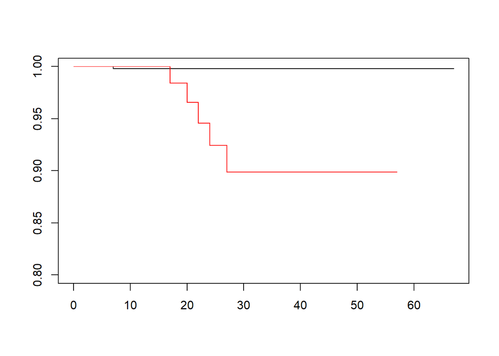

```r
e$x <- factor(ifelse(e$age > 70, ">70", "<=70"), levels = c("<=70", ">70"))
plot(survfit(Surv(time, death_status) ~ I(age > 70), data = e),
     ylim = c(0.8, 1),
     col = 1:2)
```